[figure not shown]

Animal Crossing is one of the most relaxing and friendly game series in the market today. Animal Crossing ignores many common video game aspects, such as competition and challenge, and let’s you enjoy and interact with your environment and friends. The most recent version New Horizons has sold in 31.18 million copies as of Dec 2020, making it one of the best selling games on the switch.

In this report I will be analyzing reviews of Animal Crossing and build a logistic regression model to predict ratings based on those reviews. The data is from tidytuesday dataset in the rfordatascience repo.

```r
df <- read_tsv('https://raw.githubusercontent.com/rfordatascience/tidytuesday/master/data/2020/2020-05-05/user_reviews.tsv')
```

To begin we should look at the distribution of the ratings.

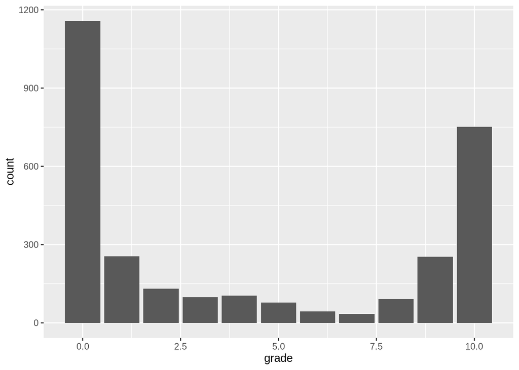

```r
df %>% ggplot(aes(x=grade)) + geom_bar()
```

The plot shows how reviews can be polarizing. People who really love the game or really hate it post the most while those who are less aggressive won’t give a review

Another good plot to look at is how review change over time

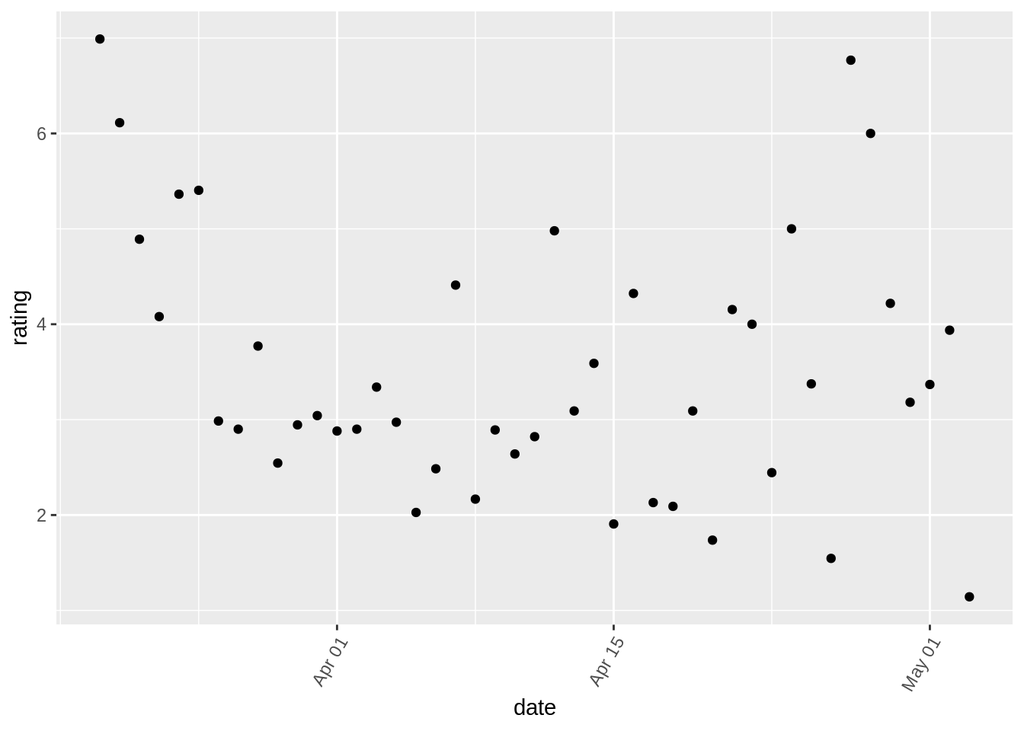

```r
df %>% group_by(date) %>%
  summarise(rating=mean(grade)) %>%
  ggplot(aes(x=date, y=rating)) + geom_point() + theme(axis.text.x = element_text(angle = 60, hjust = 1))
```

We can sample the reviews

```r
df %>% filter(grade == 10) %>% pull(text) %>% sample(3)
```

```
## [1] "Players giving this game a zero and calling themselves Animal Crossing fans are a complete joke....even without the features they are all crying like babies about... it's still a solid 8..you guys should be ashamed of yourselves"
## [2] "Amazing new addition to the already awesome series! I love how much work the dev and design teams have put towards this game! It is truly a labour of love. Wonderful graphics, new dialogue, new villagers, new concepts, crafting, and improvements on existing concepts such as house decor, outf…
## [3] "This review contains spoilers, click expand to view.                                                                                            This game is saving the sanity of the human race. Brilliantly executed. Lol review bombers.… Expand"
```

Good review comment on how the game looks great and how relaxing the sound track is.

```r
df %>% filter(grade == 0) %>% pull(text) %>% sample(3)
```

```
## [1] "I actually just made a metacritic account just to review this game. This would be an almost perfect game if it wasn't for the one island per switch feature mixed with the first player to log in be in control of the entire game's progression for all players. This is an increasing issue if you…
## [2] "Fix the game Nintendo. I bought it for me and my wife to enjoy i started the game first only to find out we have to share a single island. Annoying but no big deal. However, I then discovered that my wife cannot make any progress in the game on her own and make and executive decisions. I was…
## [3] "Zero is as low as I can go? More like -100 Really Nintendo? One island per Switch? The first user has control over everything and all others are just residents WT Actual F! I am a single dad of two teenage girls and if you knew how much grief this has caused in my household  I do not play th…
```

Bad reviews comment on how there is only one island per console, and how there is a lot of greed from Nintendo.

#### Text preprocessing

It seem like there was some issue with the scraping of the data as some reviews are repetitive. Those can be removed by filtering out the reviews with *Expand* at the end. Also a lot of the content in the reviews don’t carry any sentiment so they will be removed as well.

- Remove punctuation
- Remove stop words
- Remove words that are one letter long
- Remove white spaces

```r
stop_word_list <- c(stopwords(), 'user', 'far', 'gets', 'ac', 'want', 'day', 'things', 'que', 'always', 'since', 'reviews', 'yet', 'side', 'wasn', 'run', 'said', 'de', 'los')
df <- df %>% mutate(org_text = text,
                    text = str_remove(text, 'Expand$'),
                    text = str_to_lower(text) %>%
                           gsub(pattern = '\\W', replace=' ') %>%
                           removeWords(stop_word_list) %>%
                           gsub(pattern='\\b[a-z]\\b{1}', replace=' ') %>%
                           stripWhitespace(),
                    len = sapply(strsplit(text, ' '), length))
```

Some of those reviews were long while others are short, lets look at a histogram of the distribution of reviews

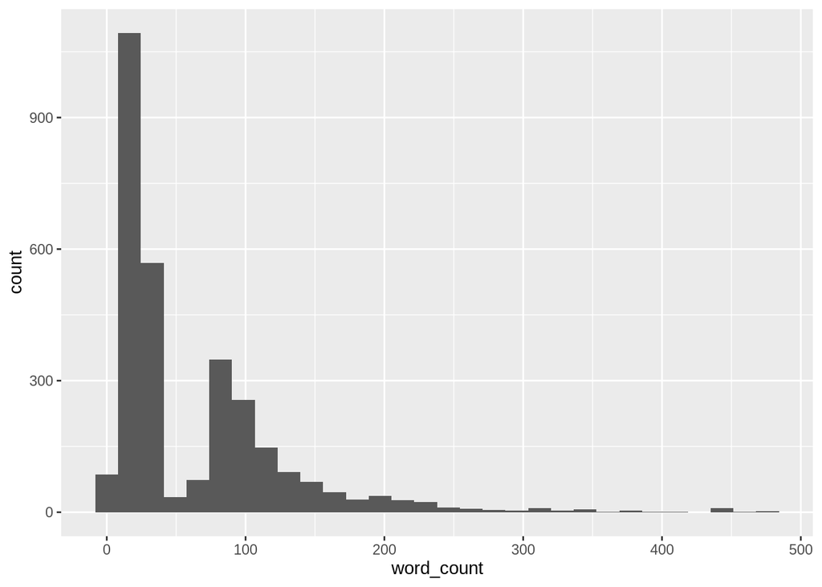

```r
df %>% unnest_tokens(word, text) %>%
  count(user_name, name='word_count') %>%
  ggplot(aes(word_count)) + geom_histogram()
```

We can also look at the difference in sentiment

```r
library(reshape2)
```

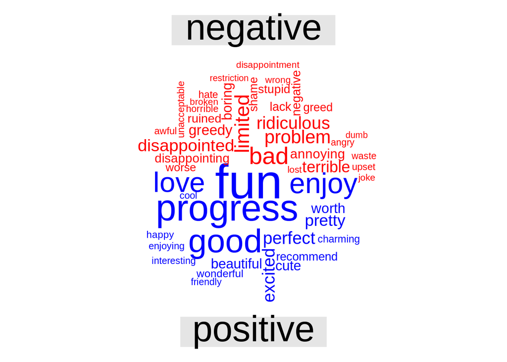

```r
library(wordcloud)
words = df %>% unnest_tokens(word, text) %>% count(word, name='word_count')

words %>% inner_join(get_sentiments('afinn')) %>%
          inner_join(get_sentiments('nrc')) %>%
          inner_join(get_sentiments('bing')) %>%
          acast(word ~ sentiment, value.var='word_count', fill=0) %>%
  comparison.cloud(colors=c('red', 'blue'), max.words = 50)
```

Creating the labels. Grades that are greater than 7 will be considered a positive review and those less than 7 negative.

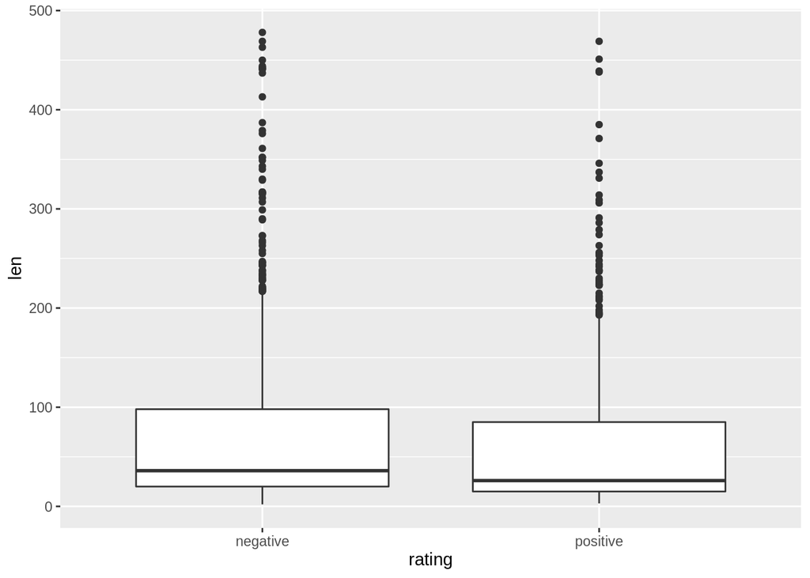

```r
df <- df %>% mutate(rating = case_when(grade > 7 ~ 'positive', TRUE ~ 'negative'))
df %>% select(rating, len) %>% ggplot(aes(x=rating, y=len)) + geom_boxplot()
```

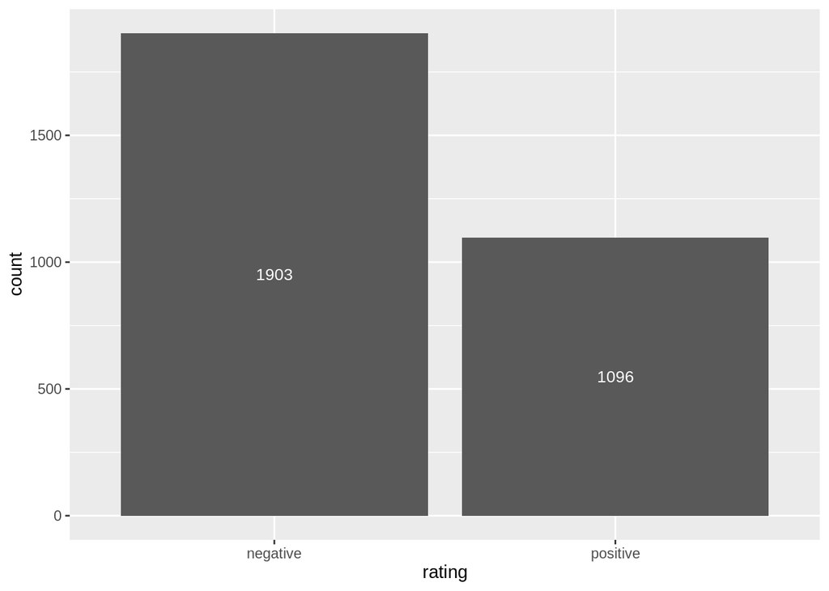

```r
df %>% ggplot(aes(rating)) + geom_bar(sstat='count') + stat_count(geom = "text", colour = "white", size = 3.5, aes(label = ..count..), position=position_stack(vjust=0.5))
```

As we saw from the first bar plot there are more negative reviews that positive ones; however the different isn’t too larger for unbalance to be an issue.

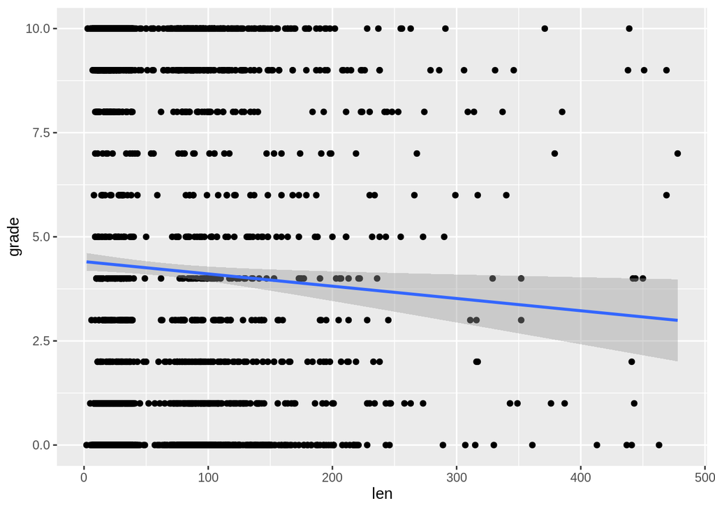

```r
df %>% ggplot(aes(x=len, y=grade)) + geom_point() + geom_smooth(method='lm')
```

```r
lmodel <- lm(grade ~ len, data=df)
summary(lmodel)
```

```
##
## Call:
## lm(formula = grade ~ len, data = df)
##
## Residuals:
##    Min     1Q Median     3Q    Max
## -4.399 -4.180 -2.097  5.614  6.891
##
## Coefficients:
##              Estimate Std. Error t value Pr(>|t|)
## (Intercept)  4.404642   0.109860  40.093   <2e-16 ***
## len         -0.002951   0.001197  -2.465   0.0138 *
## ---
## Signif. codes:  0 '***' 0.001 '**' 0.01 '*' 0.05 '.' 0.1 ' ' 1
##
## Residual standard error: 4.346 on 2997 degrees of freedom
## Multiple R-squared:  0.002023,   Adjusted R-squared:  0.00169
## F-statistic: 6.074 on 1 and 2997 DF,  p-value: 0.01378
```

#### Model building

```r
df_split <- initial_split(df, strata=rating)
df_train <- training(df_split)
df_test <- testing(df_split)
```

Before feeding the data into the model we need to quantify it for matrix operations. The process is:

- Tokenization for text
- Text filtering for text that are too frequent
- Term frequency-inverse document frequency
- Centering and scaling

```r
text_rec <- recipe(rating ~ text, data = df_train) %>%
  step_tokenize(text) %>%
  step_tokenfilter(text, max_tokens = 600) %>%
  step_tfidf(text) %>%
  step_normalize(all_predictors())
```

Build classification model with logistic regression mixture = 1 to train a lasso model

Since our labels is categorical, logistic regression is be a good fit. The glmnet R package fits a generalized linear model via penalized maximum likelihood. This method of estimating the logistic regression slope parameters uses a penalty on the process so that less relevant predictors are driven towards a value of zero.

$$\operatorname{Pr}(\text{rating} = positive \mid \text{x1, x2, x3 ...})\\
= \frac{\exp(\beta_{0} + \beta_{1} \text{amazing} + \beta_{2} \text{greed} + \dots +
\beta_{12} \text{excellent)} }{1 + \exp(\beta_{0} + \beta_{1} \text{amazing} + \beta_{2} \text{greed} + \dots + \beta_{12 }\text{excellent})} \label{eq:glm1}$$

```r
model <- logistic_reg(penalty = tune(), mixture = 1) %>% set_engine('glmnet')
model_wf <- workflow() %>%
  add_recipe(text_rec) %>%
  add_model(model)
```

#### Model tuning

```r
grid <- grid_regular(penalty(), levels=20)
folds <- bootstraps(df_train, strata = rating)
```

As one would expect model tuning is a long process so we will employ parallelism to speed up the process

```r
doParallel::registerDoParallel()

model_grid <- tune_grid(model_wf, resamples = folds, grid=grid, metrics=metric_set(roc_auc, precision, recall))
```

With the tuning process completed we can visualize the metrics

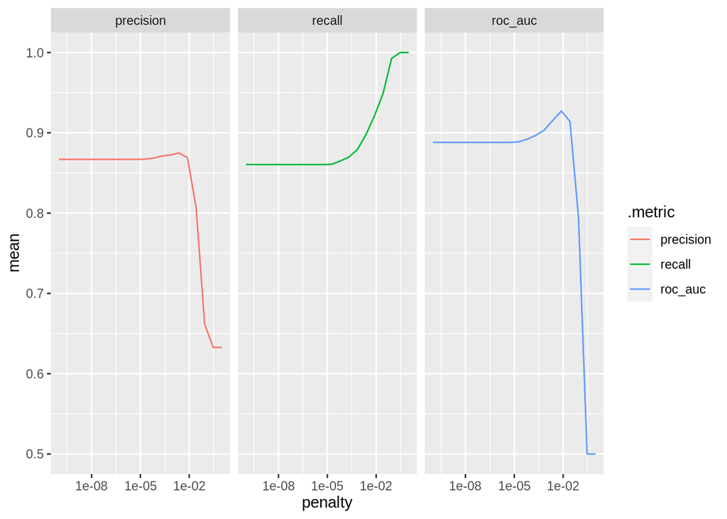

```r
model_grid %>% collect_metrics() %>% ggplot(aes(x=penalty, y=mean, color=.metric)) + geom_line() + facet_wrap(~.metric) + scale_x_log10()
```

```r
best_auc <- model_grid %>% select_best('roc_auc')
final_model <- finalize_workflow(model_wf, best_auc)
```

Now that we have tuned the model we can fit it to the training data and visualize works that correspond more to positive and negative reviews Variable importance

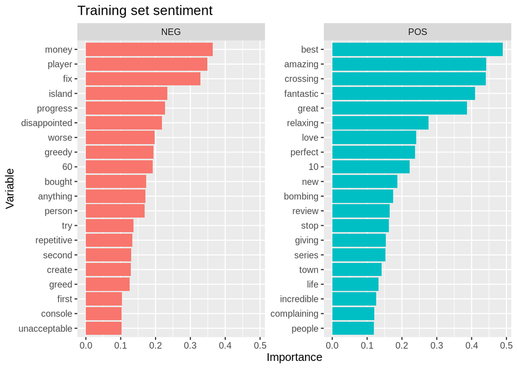

```r
y_train_pred <- final_model %>% fit(df_train) %>% pull_workflow_fit() %>% vi(lambda = best_auc$penalty)
y_train_pred %>%
  mutate(Importance = abs(Importance)) %>%
  group_by(Sign) %>%
  top_n(20, wt = Importance) %>%
  ungroup() %>%
  mutate(Variable = fct_reorder(str_remove(Variable, 'tfidf_text_'), Importance)) %>%
  ggplot(aes(x=Variable, y=Importance, fill=Sign)) + geom_col(show.legend=F) + coord_flip() + facet_wrap(~Sign, scales='free_y') + labs(title='Training set sentiment')
```

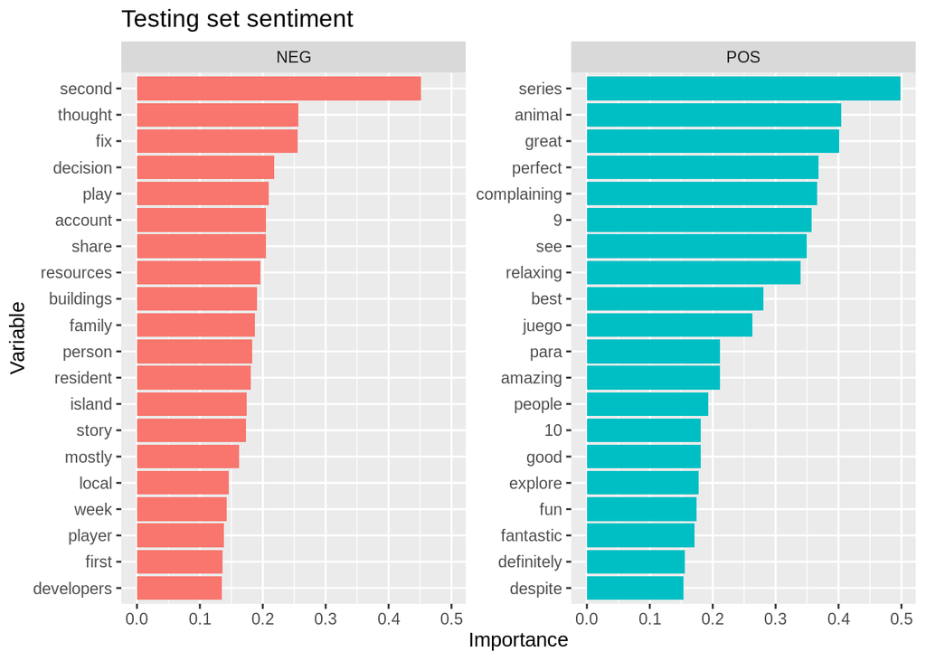

```r
y_test_pred <- final_model %>% fit(df_test) %>% pull_workflow_fit() %>% vi(lambda = best_auc$penalty)
y_test_pred %>%
  mutate(Importance = abs(Importance)) %>%
  group_by(Sign) %>%
  top_n(20, wt = Importance) %>%
  ungroup() %>%
  mutate(Variable = fct_reorder(str_remove(Variable, 'tfidf_text_'), Importance)) %>%
  ggplot(aes(x=Variable, y=Importance, fill=Sign)) + geom_col(show.legend=F) + coord_flip() + facet_wrap(~Sign, scales='free_y') + labs(title='Testing set sentiment')
```

From both the training and testing set we can users gave negative reviews based on the *$60* price tag, the fact that there was *money* and *greed* involved and a lack of *sharing* due to there being only one *island* per game. The positive reviews are about the gaming being the *best*, *amazing*, *perfect* and fun. Some of the positive reviews claim that the negative reviews are bias towards the game and are review *bombing*.

Finally we can evaluate the model performance by evaluating on the testing data

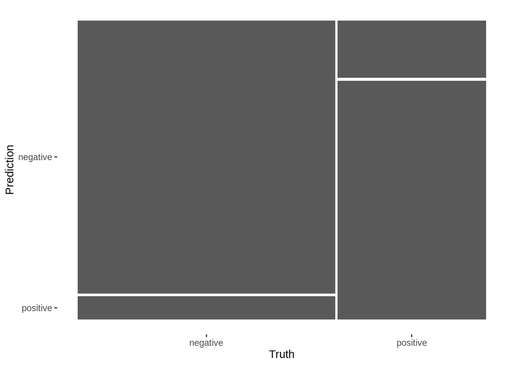

```r
review_final <- last_fit(final_model, df_split)

review_final %>% collect_predictions() %>% conf_mat(rating, .pred_class) %>% autoplot(type='mosaic')
```

```r
review_final %>% collect_predictions() %>% conf_mat(rating, .pred_class)
```

```
##           Truth
## Prediction negative positive
##   negative      438       53
##   positive       37      221
```

From the mosaic plot we can see our model does well at predicting negative values, however it struggles a little more on predicting positing examples. The confusion matrix gives the granular details.

#### Conclusion

The analysis done here is a good start but more work can be done. The text preprocessing would be a good start to remove other words that aren’t very helpful. Also increasing the number of words used for training will give the model for data to work with; however it will take longer to tune and train. Over all the current model performed well from such a simplistic approach. The steps taken for this analysis can be use on any dataset in need for sentiment analysis.